# Working with Data, Part 1

## 3. Extracting parts

dataframe is a matrix, each variable (column) is a vector

```r
#dataset[row, column]
gss100[1,2]
```

```
## [1] $4000 TO 4999
## 14 Levels: $1000 TO 2999 $10000 - 14999 $15000 - 19999 ... REFUSED
```

```r
# dataset[rows, columns]
gss100[1:5, c(2,5)]
```

```
##               income           finrela
## 37639  $4000 TO 4999 FAR BELOW AVERAGE
## 52228 $15000 - 19999 FAR BELOW AVERAGE
## 39101 $25000 OR MORE           AVERAGE
## 18321 $20000 - 24999           AVERAGE
## 36903  $8000 TO 9999     BELOW AVERAGE
```

```r
#dataset$variable, the whole column
gss100[,7]
```

```
##   [1] LT HIGH SCHOOL BACHELOR       HIGH SCHOOL    HIGH SCHOOL    HIGH SCHOOL
##   [6] LT HIGH SCHOOL HIGH SCHOOL    HIGH SCHOOL    HIGH SCHOOL    LT HIGH SCHOOL
##  [11] LT HIGH SCHOOL HIGH SCHOOL    HIGH SCHOOL    BACHELOR       BACHELOR
##  [16] HIGH SCHOOL    HIGH SCHOOL    JUNIOR COLLEGE GRADUATE       HIGH SCHOOL
##  [21] JUNIOR COLLEGE BACHELOR       HIGH SCHOOL    BACHELOR       LT HIGH SCHOOL
##  [26] LT HIGH SCHOOL HIGH SCHOOL    HIGH SCHOOL    BACHELOR       BACHELOR
##  [31] HIGH SCHOOL    HIGH SCHOOL    HIGH SCHOOL    LT HIGH SCHOOL HIGH SCHOOL
##  [36] HIGH SCHOOL    GRADUATE       BACHELOR       HIGH SCHOOL    HIGH SCHOOL
##  [41] BACHELOR       HIGH SCHOOL    HIGH SCHOOL    HIGH SCHOOL    BACHELOR
##  [46] BACHELOR       HIGH SCHOOL    JUNIOR COLLEGE BACHELOR       LT HIGH SCHOOL
##  [51] LT HIGH SCHOOL HIGH SCHOOL    LT HIGH SCHOOL HIGH SCHOOL    HIGH SCHOOL
##  [56] HIGH SCHOOL    HIGH SCHOOL    BACHELOR       HIGH SCHOOL    HIGH SCHOOL
##  [61] BACHELOR       HIGH SCHOOL    HIGH SCHOOL    BACHELOR       HIGH SCHOOL
##  [66] LT HIGH SCHOOL LT HIGH SCHOOL HIGH SCHOOL    LT HIGH SCHOOL HIGH SCHOOL
##  [71] HIGH SCHOOL    HIGH SCHOOL    LT HIGH SCHOOL JUNIOR COLLEGE GRADUATE
##  [76] BACHELOR       HIGH SCHOOL    HIGH SCHOOL    HIGH SCHOOL    LT HIGH SCHOOL
##  [81] HIGH SCHOOL    HIGH SCHOOL    HIGH SCHOOL    HIGH SCHOOL    JUNIOR COLLEGE
##  [86] LT HIGH SCHOOL BACHELOR       LT HIGH SCHOOL BACHELOR       HIGH SCHOOL
##  [91] GRADUATE       HIGH SCHOOL    HIGH SCHOOL    HIGH SCHOOL    BACHELOR
##  [96] HIGH SCHOOL    JUNIOR COLLEGE LT HIGH SCHOOL GRADUATE       HIGH SCHOOL
## Levels: BACHELOR GRADUATE HIGH SCHOOL JUNIOR COLLEGE LT HIGH SCHOOL
```

```r
gss100$marital
```

```
##   [1] WIDOWED       MARRIED       MARRIED       MARRIED       NEVER MARRIED
##   [6] MARRIED       MARRIED       NEVER MARRIED NEVER MARRIED MARRIED
##  [11] MARRIED       NEVER MARRIED MARRIED       MARRIED       MARRIED
##  [16] DIVORCED      MARRIED       DIVORCED      MARRIED       MARRIED
##  [21] MARRIED       MARRIED       NEVER MARRIED NEVER MARRIED NEVER MARRIED
##  [26] MARRIED       MARRIED       MARRIED       MARRIED       MARRIED
##  [31] DIVORCED      DIVORCED      WIDOWED       NEVER MARRIED WIDOWED
##  [36] MARRIED       DIVORCED      DIVORCED      DIVORCED      NEVER MARRIED
##  [41] MARRIED       DIVORCED      DIVORCED      MARRIED       MARRIED
##  [46] DIVORCED      MARRIED       MARRIED       NEVER MARRIED MARRIED
##  [51] DIVORCED      NEVER MARRIED DIVORCED      MARRIED       NEVER MARRIED
##  [56] MARRIED       NEVER MARRIED MARRIED       MARRIED       MARRIED
##  [61] SEPARATED     MARRIED       MARRIED       NEVER MARRIED DIVORCED
##  [66] DIVORCED      DIVORCED      DIVORCED      MARRIED       WIDOWED
##  [71] NEVER MARRIED DIVORCED      NEVER MARRIED NEVER MARRIED MARRIED
##  [76] MARRIED       DIVORCED      DIVORCED      MARRIED       MARRIED
##  [81] MARRIED       NEVER MARRIED DIVORCED      DIVORCED      DIVORCED
##  [86] DIVORCED      NEVER MARRIED WIDOWED       MARRIED       DIVORCED
##  [91] MARRIED       MARRIED       MARRIED       MARRIED       NEVER MARRIED
##  [96] MARRIED       NEVER MARRIED DIVORCED      DIVORCED      MARRIED
## Levels: DIVORCED MARRIED NEVER MARRIED SEPARATED WIDOWED
```

```r
# dataset$variable[rows]
gss100$marital[1:10]
```

```
##  [1] WIDOWED       MARRIED       MARRIED       MARRIED       NEVER MARRIED
##  [6] MARRIED       MARRIED       NEVER MARRIED NEVER MARRIED MARRIED
## Levels: DIVORCED MARRIED NEVER MARRIED SEPARATED WIDOWED
```

## 4. Basic plots:

See R reference card:  
- one variable: histogram  
- one categorical: barplot(categorical)  
- two variables: scatterplot(two quant), side-by-side boxplot(quant vs cat)

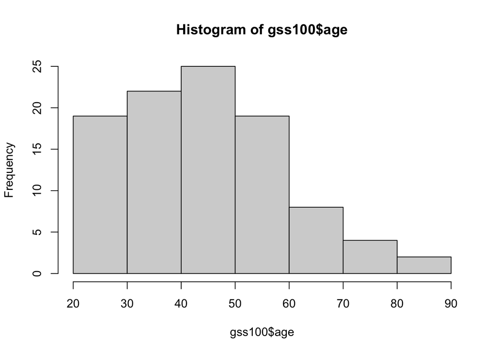

```r
# one quantitative variable:
hist(gss100$age)
```

```r
mean(gss100$age)
```

```
## [1] NA
```

```r
sd(gss100$age)
```

```
## [1] NA
```

```r
# one categorical variable:
# barplot(frequency table)
table(gss100$marital)
```

```
##
##      DIVORCED       MARRIED NEVER MARRIED     SEPARATED       WIDOWED
##            26            47            21             1             5
```

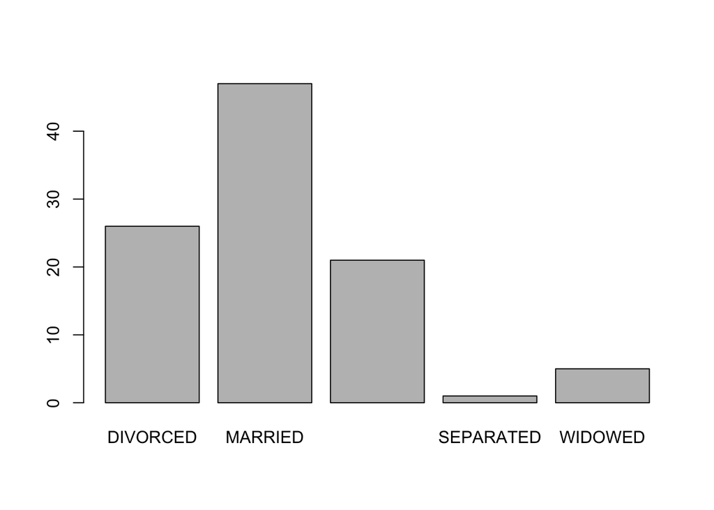

```r
barplot(table(gss100$marital))
```

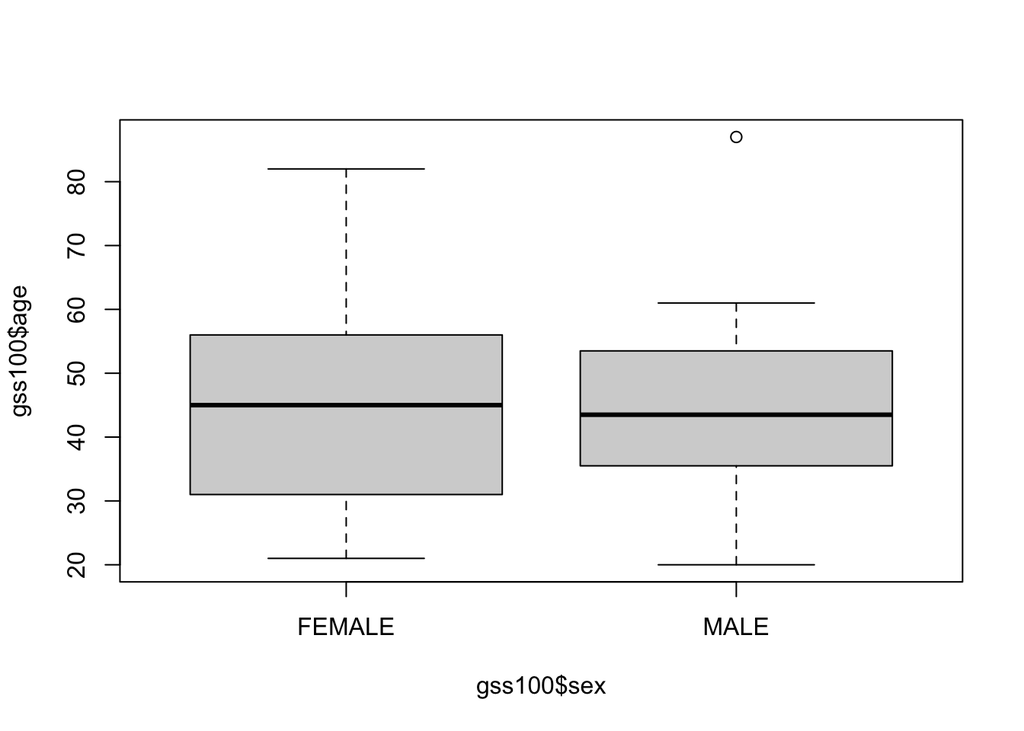

```r
# one quantitative vs one categorical
boxplot(gss100$age~gss100$sex)
```

```r
# two quantitative variables
# plot(x,y)
```

## 5. Vectors

Almost everything in R is a vector. All elements(values) of a vector must be of the same type.

```r
# str() can tell us
str(gss100)
```

```
## 'data.frame':    100 obs. of  13 variables:
##  $ region  : Factor w/ 10 levels "E. NOR. CENTRAL",..: 3 6 1 10 7 8 7 1 1 8 ...
##  $ income  : Factor w/ 14 levels "$1000 TO 2999",..: 7 3 5 4 11 6 5 2 4 11 ...
##  $ happy   : Factor w/ 4 levels "DK","NOT TOO HAPPY",..: 2 3 3 3 2 3 4 3 3 3 ...
##  $ age     : int  71 61 41 30 26 60 29 20 27 35 ...
##  $ finrela : Factor w/ 6 levels "ABOVE AVERAGE",..: 6 6 2 2 3 2 1 2 3 2 ...
##  $ marital : Factor w/ 5 levels "DIVORCED","MARRIED",..: 5 2 2 2 3 2 2 3 3 2 ...
##  $ degree  : Factor w/ 5 levels "BACHELOR","GRADUATE",..: 5 1 3 3 3 5 3 3 3 5 ...
##  $ health  : Factor w/ 6 levels "DK","EXCELLENT",..: 6 5 NA NA 4 4 2 2 NA 2 ...
##  $ wrkstat : Factor w/ 8 levels "KEEPING HOUSE",..: 1 8 7 7 7 8 7 4 7 7 ...
##  $ partyid : Factor w/ 8 levels "IND NEAR DEM",..: 4 8 5 4 4 8 5 1 2 3 ...
##  $ polviews: Factor w/ 8 levels "CONSERVATIVE",..: 7 1 7 6 6 NA 7 5 5 5 ...
##  $ sex     : Factor w/ 2 levels "FEMALE","MALE": 1 2 1 1 1 2 1 2 1 2 ...
##  $ year    : int  2000 2010 2000 1986 2000 1973 1998 1974 1986 1977 ...
```

There are four types of atomic vectors in R.

### 1) NUMERIC VECTOR (integer and Double)

A numeric vector is a list of numbers. Integer and double vectors are known collectively as numeric vectors. (Doubles represent floating point numbers that can not always be precisely represented with a fixed amount of memory.)

The *c()* function is used to collect things together into a vector. The output is

```r
c(1,2,3)
```

```
## [1] 1 2 3
```

```r
# We can save this to a named object:
x<-c(1:10)  # The : sybmbol used to create a sequence of increasing (or decreasing) values
x
```

```
##  [1]  1  2  3  4  5  6  7  8  9 10
```

```r
y<-c(30:1)
y
```

```
##  [1] 30 29 28 27 26 25 24 23 22 21 20 19 18 17 16 15 14 13 12 11 10  9  8  7  6
## [26]  5  4  3  2  1
```

```r
# use the square bracket to extract the element(value)
x[5]
```

```
## [1] 5
```

```r
x[c(1,3,5)]
```

```
## [1] 1 3 5
```

```r
x[3:7]
```

```
## [1] 3 4 5 6 7
```

```r
x[-c(1,3,5,7,9)]
```

```
## [1]  2  4  6  8 10
```

#### *seq(), rep(), sample()*

There are simple patterned numeric vectors can also be produced using the *seq()* function, the *rep()* function, and the *sample()* function.

```r
# seq(start, end, by=1)
seq(0,100,by=5) # the sequence of numbers from 0 to 100 with the increment is 5
```

```
##  [1]   0   5  10  15  20  25  30  35  40  45  50  55  60  65  70  75  80  85  90
## [20]  95 100
```

```r
# rep(x, times of repetition)
rep(2,5)    # repeat the value 2, 5 times
```

```
## [1] 2 2 2 2 2
```

```r
x<-c(1:5)
rep(x,2)  # repeat x twice
```

```
##  [1] 1 2 3 4 5 1 2 3 4 5
```

```r
y<-c(10:15)
rep(c(x,y),2)  # repeat x and y, twice
```

```
##  [1]  1  2  3  4  5 10 11 12 13 14 15  1  2  3  4  5 10 11 12 13 14 15
```

```r
# take a random sample, we can use sample() function.

# sample(vector, sample size, replace=T/F)

set.seed(1234)
sample(1:30, 5, replace=TRUE)
```

```
## [1] 28 16 26 22  5
```

```r
# randomly choose 5 numbers from 1 to 30 with replacement
# set.seed() is used to fix the starting point to get a random sample, make sure to get the same sample when the code is executed each time
```

#### Numeric vector arithmetic

Arithmetic can be done on R vectors. Note that the computation is performed *elementwise*.

```r
## Be sure to check all the results by doing it yourself!
x<-c(1:5)
x*2
x^2
7 %% 2  # the modular operator, the remainder of the division of 7 by 2.
7 %/% 2

x %% 2 # odd number and even number

y<-c(6:10)

x+y  # the same length
y-x
```

The operation functions in R can be done on numeric vectors as well.

```r
## Again, be sure to check all the results by doing it yourself!
x
sum(x)
mean(x)
length(x)
avg_x<-sum(x)/length(x)
avg_x
```

Example 1:

```r
a<-c(1, 5, 6, 8, 9, 15, 20, 19, 10)
# check odd numbers:
sum(a%%2) # Think about how this operation gives you the correct output of the number of odd observations in this vector
```

```
## [1] 5
```

### 2) CHARACTER VECTOR

Vectors can be made up of strings of characters instead of numbers.

```r
schoolyear<-c("Freshman","Sophomore","Junior","Senior")

schoolyear
```

```
## [1] "Freshman"  "Sophomore" "Junior"    "Senior"
```

```r
x<-c(2,4, 3,1)

# give the names to the numeric vector with the character vector
names(x)<-schoolyear
x
```

```
##  Freshman Sophomore    Junior    Senior
##         2         4         3         1
```

#### *substr() and paste()*

There are two basic operations you might want to perform on character vectors.

The *substr()* funcion takes subtrings, it takes arguments *substr(x, start, stop)*, where x is a vector of characters(strings), and *start* and *stop* say which chacarters to keep.

The other basis operation is building up strings by concatenation. Use the *paste()* function for this.

*tolower()* and *toupper()* are functions to convert upper case and lower case.

```r
substr(schoolyear,1,2)
```

```
## [1] "Fr" "So" "Ju" "Se"
```

```r
scoolyear1<-paste(schoolyear,"Year")

paste("The",schoolyear,"Year", sep=" ")
```

```
## [1] "The Freshman Year"  "The Sophomore Year" "The Junior Year"
## [4] "The Senior Year"
```

```r
tolower(schoolyear)
```

```
## [1] "freshman"  "sophomore" "junior"    "senior"
```

Example 2:

```r
substr(state.name, 1, 1)
```

```
##  [1] "A" "A" "A" "A" "C" "C" "C" "D" "F" "G" "H" "I" "I" "I" "I" "K" "K" "L" "M"
## [20] "M" "M" "M" "M" "M" "M" "M" "N" "N" "N" "N" "N" "N" "N" "N" "O" "O" "O" "P"
## [39] "R" "S" "S" "T" "T" "U" "V" "V" "W" "W" "W" "W"
```

```r
# translate all the state names to lower case
tolower(state.name)
```

```
##  [1] "alabama"        "alaska"         "arizona"        "arkansas"
##  [5] "california"     "colorado"       "connecticut"    "delaware"
##  [9] "florida"        "georgia"        "hawaii"         "idaho"
## [13] "illinois"       "indiana"        "iowa"           "kansas"
## [17] "kentucky"       "louisiana"      "maine"          "maryland"
## [21] "massachusetts"  "michigan"       "minnesota"      "mississippi"
## [25] "missouri"       "montana"        "nebraska"       "nevada"
## [29] "new hampshire"  "new jersey"     "new mexico"     "new york"
## [33] "north carolina" "north dakota"   "ohio"           "oklahoma"
## [37] "oregon"         "pennsylvania"   "rhode island"   "south carolina"
## [41] "south dakota"   "tennessee"      "texas"          "utah"
## [45] "vermont"        "virginia"       "washington"     "west virginia"
## [49] "wisconsin"      "wyoming"
```

### 3) LOGICAL VECTOR

R also supports **logical** vectors, where the values are either *TRUE* or *FALSE*. It is often necessary to test relations when programming. R allows testing of equality and inequality relations using the relational operators:

1. greater than: $>$,
2. less than: $<$,
3. equality: $==$,
4. inequality: $!=$, $>=$, $<=$,
5. matching: $ %in% $.

For example, we can ask

```r
x<-c(1:5)
x>3
```

```
## [1] FALSE FALSE FALSE  TRUE  TRUE
```

```r
3==4
```

```
## [1] FALSE
```

```r
schoolyear %in% "Senior"
```

```
## [1] FALSE FALSE FALSE  TRUE
```

With a logical data result, *TRUE* has an internal value of 1 and FALSE has an internal value of 0. Summing a logical will evaluate the total number of *TRUE* results.

```r
sum(x>3)
```

```
## [1] 2
```

The logical (boolean) operation is very helpful to extract subsets by *subset(logical expression)*

```r
gss100subset<-gss100[gss100$year==2010,]
head(gss100subset)
```

```
##                region         income         happy age           finrela
## 52228    NOT ASSIGNED $15000 - 19999  PRETTY HAPPY  61 FAR BELOW AVERAGE
## 52394 E. NOR. CENTRAL $25000 OR MORE    VERY HAPPY  56 FAR ABOVE AVERAGE
## 52941    NOT ASSIGNED $10000 - 14999 NOT TOO HAPPY  45     BELOW AVERAGE
##             marital      degree health          wrkstat           partyid
## 52228       MARRIED    BACHELOR    IAP WORKING PARTTIME STRONG REPUBLICAN
## 52394       MARRIED    BACHELOR    IAP WORKING FULLTIME STRONG REPUBLICAN
## 52941 NEVER MARRIED HIGH SCHOOL   FAIR TEMP NOT WORKING      IND NEAR REP
##               polviews    sex year
## 52228     CONSERVATIVE   MALE 2010
## 52394     CONSERVATIVE FEMALE 2010
## 52941 SLIGHTLY LIBERAL   MALE 2010
```

```r
names(gss100subset)
```

```
##  [1] "region"   "income"   "happy"    "age"      "finrela"  "marital"
##  [7] "degree"   "health"   "wrkstat"  "partyid"  "polviews" "sex"
## [13] "year"
```

```r
state.name[substr(state.name,1,1)=="N"]
```

```
## [1] "Nebraska"       "Nevada"         "New Hampshire"  "New Jersey"
## [5] "New Mexico"     "New York"       "North Carolina" "North Dakota"
```

```r
schoolyear[substr(schoolyear,1,1)=="S"]
```

```
## [1] "Sophomore" "Senior"
```

The logical operators are very useful to get a subset.

```r
# subset(data/vector, logical expression)
```

#### Boolean operation

The Boolean operations can be encoded in R. $\&$ and $|$ mean *and* and *or*, $!$ means negative. These operations are very important to make a subset.

```r
x<-c(1:20)

x1<-subset(x, (x>10) & (x==12))
x1
```

```
## [1] 12
```

```r
x2<-subset(x, (x<=5) | (x>14))
x2
```

```
##  [1]  1  2  3  4  5 15 16 17 18 19 20
```

```r
gss2<-gss[gss$year==2010, ]
```

#### *is.XXX()*

##### *is.na()* and *!is.na()* is used to detect the missing values in the dataset

```r
sum(is.na(gss$marital))
```

```
## [1] 20
```

```r
sum(is.na(gss$region))
```

```
## [1] 0
```

```r
sum(is.na(gss$age))
```

```
## [1] 189
```

```r
sum(is.na(gss$age[gss$region=="SOUTH ATLANTIC"]))
```

```
## [1] 41
```

```r
# the missing values
mean(gss$age[gss$region=="SOUTH ATLANTIC"], na.rm = TRUE)
```

```
## [1] 46.19038
```

##### *is.vectortype()* is used to check the type of the vector.

```r
is.character(state.name)
```

```
## [1] TRUE
```

```r
is.numeric(gss$age)
```

```
## [1] TRUE
```

```r
is.character(gss$marital)
```

```
## [1] FALSE
```

```r
str(gss)
```

```
## 'data.frame':    53474 obs. of  13 variables:
##  $ region  : Factor w/ 10 levels "E. NOR. CENTRAL",..: 1 1 1 1 1 3 3 3 3 3 ...
##  $ income  : Factor w/ 14 levels "$1000 TO 2999",..: 2 10 2 2 2 2 7 10 1 3 ...
##  $ happy   : Factor w/ 4 levels "DK","NOT TOO HAPPY",..: 2 4 3 3 3 3 4 3 3 4 ...
##  $ age     : int  54 51 36 32 54 41 31 26 78 46 ...
##  $ finrela : Factor w/ 6 levels "ABOVE AVERAGE",..: 2 2 2 2 2 2 2 2 3 1 ...
##  $ marital : Factor w/ 5 levels "DIVORCED","MARRIED",..: 2 2 2 2 2 1 2 3 5 2 ...
##  $ degree  : Factor w/ 5 levels "BACHELOR","GRADUATE",..: 5 5 5 3 5 3 5 1 5 1 ...
##  $ health  : Factor w/ 6 levels "DK","EXCELLENT",..: 3 4 2 2 4 4 2 4 6 3 ...
##  $ wrkstat : Factor w/ 8 levels "KEEPING HOUSE",..: 7 1 7 7 1 7 1 7 1 7 ...
##  $ partyid : Factor w/ 8 levels "IND NEAR DEM",..: 6 4 2 4 2 4 1 4 4 2 ...
##  $ polviews: Factor w/ 8 levels "CONSERVATIVE",..: NA NA NA NA NA NA NA NA NA NA ...
##  $ sex     : Factor w/ 2 levels "FEMALE","MALE": 2 1 1 2 1 1 1 2 1 2 ...
##  $ year    : int  1973 1973 1973 1973 1973 1973 1973 1973 1973 1973 ...
```

### 4) FACTOR

The factors are used to store categorical variables with numeric data. labels + numbers. *factor()* is used to create a new factor. *is.XXX()* and *class()* are used to check specific type, *as.XXX()* is used to cast vectors to specific type.

```r
str(gss)
```

```
## 'data.frame':    53474 obs. of  13 variables:
##  $ region  : Factor w/ 10 levels "E. NOR. CENTRAL",..: 1 1 1 1 1 3 3 3 3 3 ...
##  $ income  : Factor w/ 14 levels "$1000 TO 2999",..: 2 10 2 2 2 2 7 10 1 3 ...
##  $ happy   : Factor w/ 4 levels "DK","NOT TOO HAPPY",..: 2 4 3 3 3 3 4 3 3 4 ...
##  $ age     : int  54 51 36 32 54 41 31 26 78 46 ...
##  $ finrela : Factor w/ 6 levels "ABOVE AVERAGE",..: 2 2 2 2 2 2 2 2 3 1 ...
##  $ marital : Factor w/ 5 levels "DIVORCED","MARRIED",..: 2 2 2 2 2 1 2 3 5 2 ...
##  $ degree  : Factor w/ 5 levels "BACHELOR","GRADUATE",..: 5 5 5 3 5 3 5 1 5 1 ...
##  $ health  : Factor w/ 6 levels "DK","EXCELLENT",..: 3 4 2 2 4 4 2 4 6 3 ...
##  $ wrkstat : Factor w/ 8 levels "KEEPING HOUSE",..: 7 1 7 7 1 7 1 7 1 7 ...
##  $ partyid : Factor w/ 8 levels "IND NEAR DEM",..: 6 4 2 4 2 4 1 4 4 2 ...
##  $ polviews: Factor w/ 8 levels "CONSERVATIVE",..: NA NA NA NA NA NA NA NA NA NA ...
##  $ sex     : Factor w/ 2 levels "FEMALE","MALE": 2 1 1 2 1 1 1 2 1 2 ...
##  $ year    : int  1973 1973 1973 1973 1973 1973 1973 1973 1973 1973 ...
```

```r
levels(gss$region) # a factor has its own levels, labels + numbers
```

```
##  [1] "E. NOR. CENTRAL" "E. SOU. CENTRAL" "MIDDLE ATLANTIC" "MOUNTAIN"
##  [5] "NEW ENGLAND"     "NOT ASSIGNED"    "PACIFIC"         "SOUTH ATLANTIC"
##  [9] "W. NOR. CENTRAL" "W. SOU. CENTRAL"
```

```r
schoolyear<-c("Freshman","Sophomore","Freshman","Sophomore","Senior","Freshman","Sophomore","Junior")
class(schoolyear)
```

```
## [1] "character"
```

```r
is.factor(schoolyear)
```

```
## [1] FALSE
```

```r
factor(schoolyear)
```

```
## [1] Freshman  Sophomore Freshman  Sophomore Senior    Freshman  Sophomore
## [8] Junior
## Levels: Freshman Junior Senior Sophomore
```

```r
is.factor(schoolyear)
```

```
## [1] FALSE
```

```r
schoolyear_factor<-as.factor(schoolyear)
is.factor(schoolyear_factor)
```

```
## [1] TRUE
```

```r
levels(schoolyear_factor)  # alphabetical order by default
```

```
## [1] "Freshman"  "Junior"    "Senior"    "Sophomore"
```

```r
schoolyear_number<-as.numeric(schoolyear_factor)
schoolyear_number
```

```
## [1] 1 4 1 4 3 1 4 2
```

```r
table(schoolyear)   # categorical variable is summarized by frequency table
```

```
## schoolyear
##  Freshman    Junior    Senior Sophomore
##         3         1         1         3
```

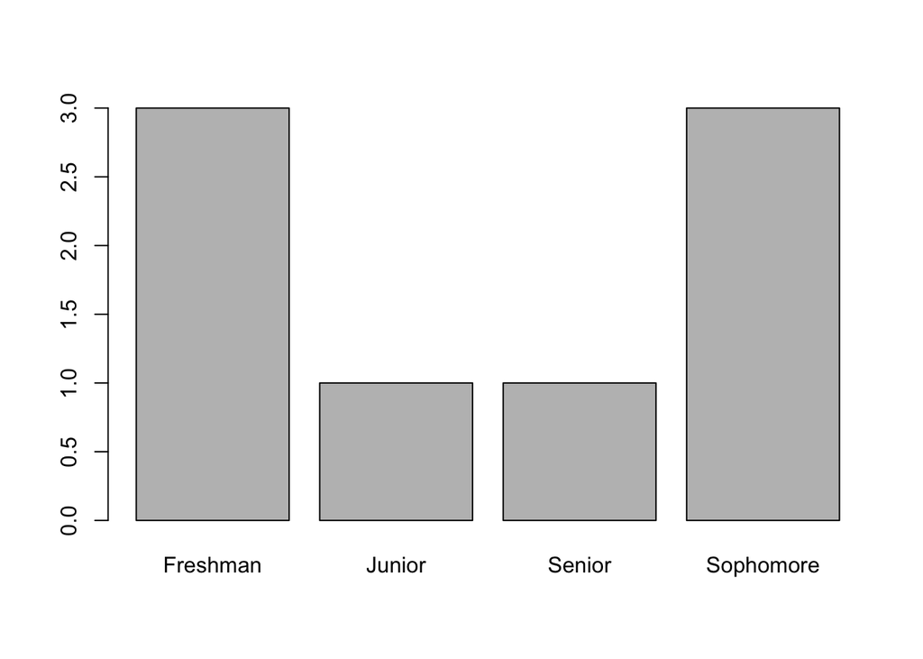

```r
barplot(table(schoolyear)) # barplot(frequency table)
barplot(table(schoolyear_factor))
```

#### Reorder the levels of the factor.

The original factor order is alphabetical. You can change ordering of the levels:

```r
# change ordering of the levels
# vector<-factor(vector, levels=c("level1","level2","level3"))

schoolyear_factor<-factor(schoolyear, levels = c("Freshman","Sophomore","Junior","Senior"))

levels(schoolyear_factor)
```

```
## [1] "Freshman"  "Sophomore" "Junior"    "Senior"
```

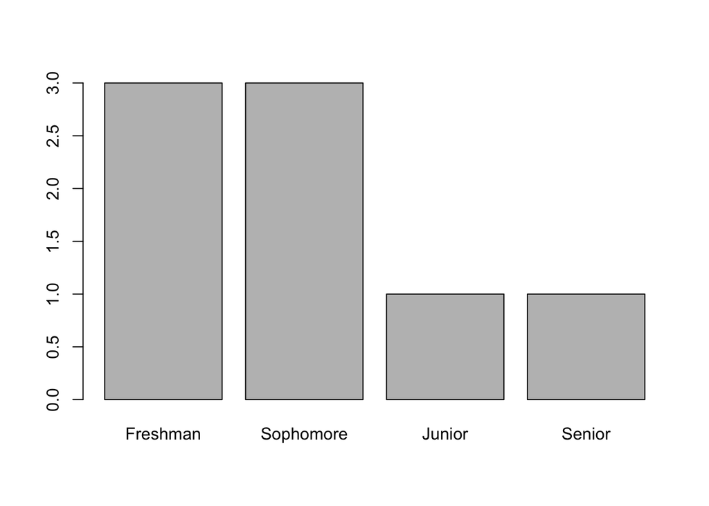

```r
barplot(table(schoolyear_factor))
```

#### Recode a factor / Re-assign levels to a factor

Change values of a factor to NA

```r
levels(gss$happy)
```

```
## [1] "DK"            "NOT TOO HAPPY" "PRETTY HAPPY"  "VERY HAPPY"
```

```r
# creating a new variable by copying the original one, making changes on the new one,
# so that we don't change the orginial data

# create a new factor
# new vector<-factor(vector, levels=c("level1","level2","level3"))

gss$happy1<-factor(gss$happy,levels=c("NOT TOO HAPPY","PRETTY HAPPY", "VERY HAPPY"))

gss$happy1[gss$happy=="NOT TOO HAPPY"]<-"NOT TOO HAPPY"

gss$happy1[gss$happy=="PRETTY HAPPY"]<-"PRETTY HAPPY"

gss$happy1[gss$happy=="VERY HAPPY"]<-"VERY HAPPY"

gss$happy1[gss$happy==" " | gss$happy=="DK"]<-NA

levels(gss$happy1)
```

```
## [1] "NOT TOO HAPPY" "PRETTY HAPPY"  "VERY HAPPY"
```

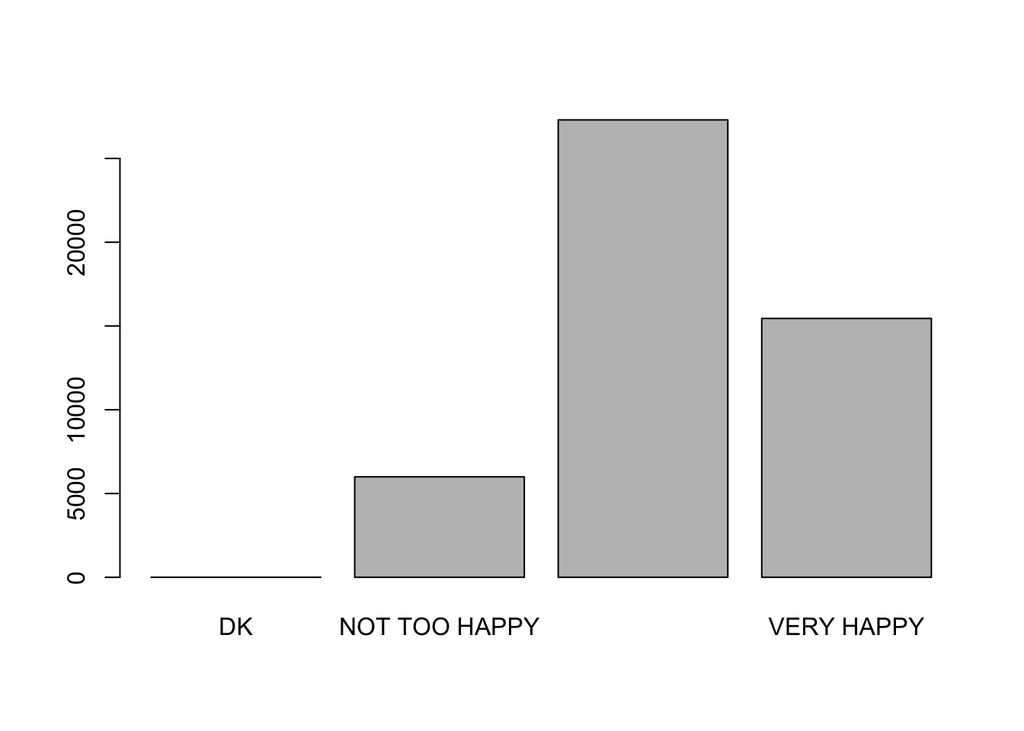

```r
barplot(table(gss$happy))
```

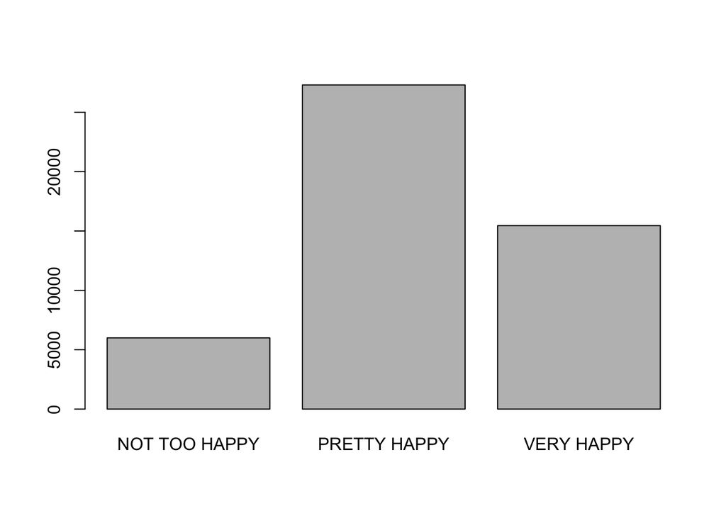

```r
barplot(table(gss$happy1))
```

#### Create a binary factor (shortcut *ifelse()*)

```r
gss$happy2<-factor(ifelse(gss$happy=="VERY HAPPY","HAPPY","NOT HAPPY"))

summary(gss$happy)
```

```
##            DK NOT TOO HAPPY  PRETTY HAPPY    VERY HAPPY          NA's
##             2          5997         27303         15451          4721
```

```r
summary(gss$happy2)
```

```
##     HAPPY NOT HAPPY      NA's
##     15451     33302      4721
```

## 6. Casting Vectors

**This topic will be discussed in “Working with data, part 2” next week.**

## Getting help

```r
 ?hist()
# then look for specific help by using cmd+f for Mac or ctrl+f for Windows!
```